# Corona - Fallzahlenauswertung

### Datenquelle, Abrufzeitpunkt

| Amtliche RKI-Corona-Daten für Land-/Stadtkreis | Abrufzeitpunkt |
| --- | --- |
| Passau, kreisfreie Stadt | Donnerstag, 11.03.2021, 07:13:20 |

[Link zur Datenbeschreibung des RKI](https://www.arcgis.com/home/item.html?id=dd4580c810204019a7b8eb3e0b329dd6)

### Inzidenzrelevanter Zeitraum

| von - bis | nicht mehr in der Inzidenzzahl |
| --- | --- |
| Do, 04.03.2021 - Mi, 10.03.2021 | Mi, 03.03.2021 und älter |

### Veränderungen zum Vortag

```
##   Meldedatum    Art Fallzahl Inzidenzrelevant
## 1 2021-03-04 Storno       -1               Ja
## 2 2021-03-09    Neu       13               Ja
## 3 2021-03-10    Neu        7               Ja
```

### Wochenübersicht

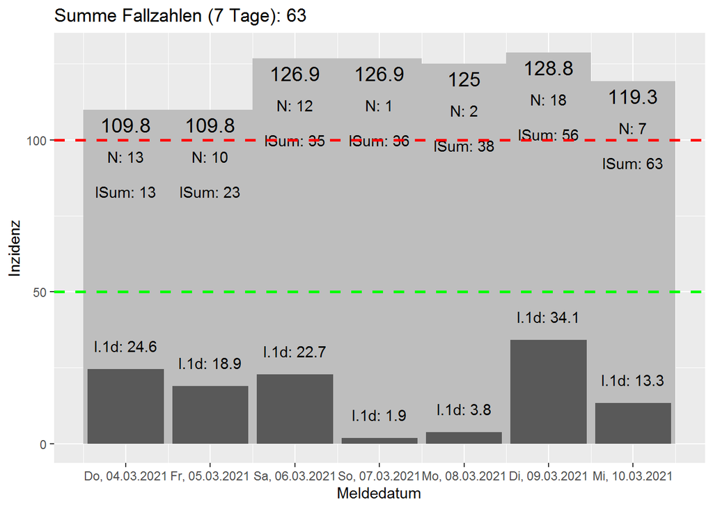

Erläuterung der Zahlenangaben:  
**N**: Anzahl der neu und nachträglich gemeldeten abzüglich der gestrichenen Fälle des jeweiligen Tages  
**I.1d** (“1-Tages-Inzidenz”): Höhe des Beitrags, den dieser Tag zur Wocheninzidenz leistet  
**lSum**: Aggregierte Summe der Fallzahlen über den Verlauf der beobachteten Woche. Der erste Tag entspricht diesem einzelnen Tag (und fällt als nächstes aus der Inzidenz), der letzte Tag entspricht der Wochen-Inzidenz.

### Über-/Unterschreitungen der geltenden Grenzwerte

```
##   Grenzwert bei_Fallzahl Abweichung
## 1        50           26        +37
## 2       100           52        +11
```

### Gesicherter Ausblick (absehbare Streichungen)

Aktuelle Inzidenz: 119.3, basierend auf den insgesamt 63 Fällen der letzten Woche.

[output not shown]

Die Fallzahlen der nächsten Tage sowie eventuelle Nachmeldungen sind dabei nicht vorhersehbar. Der maximale Rückgang wird nur erreicht, wenn bis zu diesem Tag per Saldo kein neuer Fall erfasst wird.

### Ungesicherter Ausblick

Fallzahlen gehen je nach Wochentag in unterschiedlicher Höhe ein. Basierend auf den letzten 3 Wochen bzw. 21 Tagen ergibt sich folgende Verteilung:

```
##    Wochentag Fallzahl_Durchschnitt DoW
## 1    Sonntag                  0.67   1
## 2     Montag                  2.33   2
## 3   Dienstag                 17.33   3
## 4   Mittwoch                  9.33   4
## 5 Donnerstag                  9.67   5
## 6    Freitag                  9.33   6
## 7    Samstag                  5.33   7
```

…auf der Grundlage folgender Fallzahlen der letzten 3 Wochen:

```
##    Meldedatum AnzahlFall  Wochentag
## 1  2021-02-18         14 Donnerstag
## 2  2021-02-19          8    Freitag
## 3  2021-02-20          1    Samstag
## 4  2021-02-21          0    Sonntag
## 5  2021-02-22          2     Montag
## 6  2021-02-23         18   Dienstag
## 7  2021-02-24          9   Mittwoch
## 8  2021-02-25          2 Donnerstag
## 9  2021-02-26         10    Freitag
## 10 2021-02-27          3    Samstag
## 11 2021-02-28          1    Sonntag
## 12 2021-03-01          3     Montag
## 13 2021-03-02         16   Dienstag
## 14 2021-03-03         12   Mittwoch
## 15 2021-03-04         13 Donnerstag
## 16 2021-03-05         10    Freitag
## 17 2021-03-06         12    Samstag
## 18 2021-03-07          1    Sonntag
## 19 2021-03-08          2     Montag
## 20 2021-03-09         18   Dienstag
## 21 2021-03-10          7   Mittwoch
```

### Blick in die Kristallkugel

Hier werden drei verschiedene Szenarien dargestellt:  
* Optimistische Variante 0 (Grün): Es treten keine Fälle mehr auf, somit dauert es noch 7 Tage, bis alle Inzidenzfälle abgeschmolzen sind.  
* Realistische Variante 1 (schwarz): Täglich kommen die durchschnittlichen Fälle für den jeweiligen Wochentag hinzu, was dem Abschmelzen aus Variante 0 entgegenwirkt.  
* Pessimistische Variante 2 (Rot): Wie Variante 1, nur kommt täglich der DOPPELTE Durchschnitt für den jeweiligen Wochentag hinzu. Dieser Zuwachs stellt keineswegs das obere Limit des möglichen dar.

**Bitte beachten: Im Folgenden stellt die Zeitachse das Veröffentlichungsdatum dar, nicht das Meldedatum, und ist somit um einen Tag verschoben!**

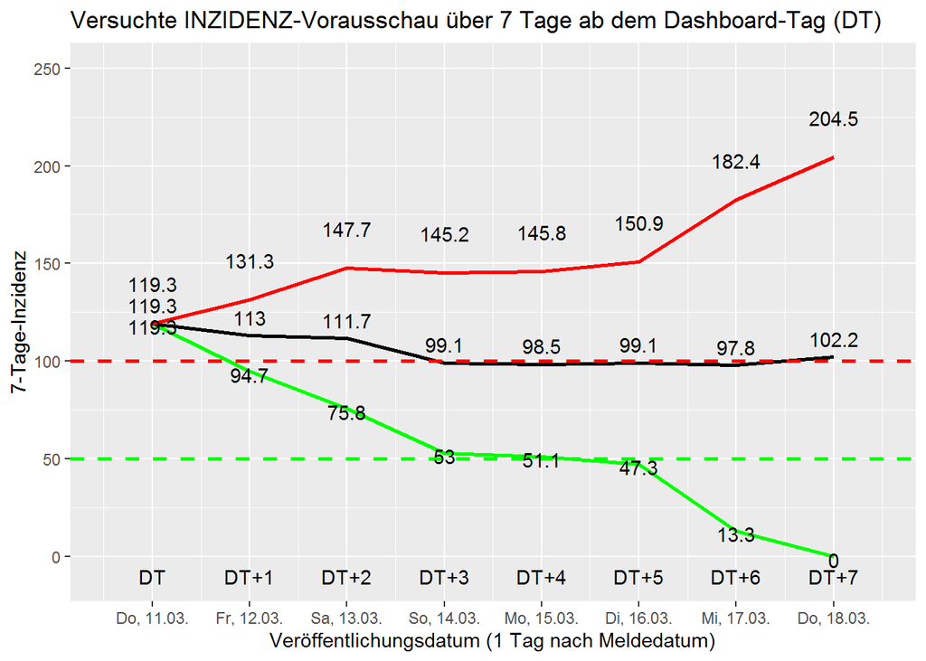

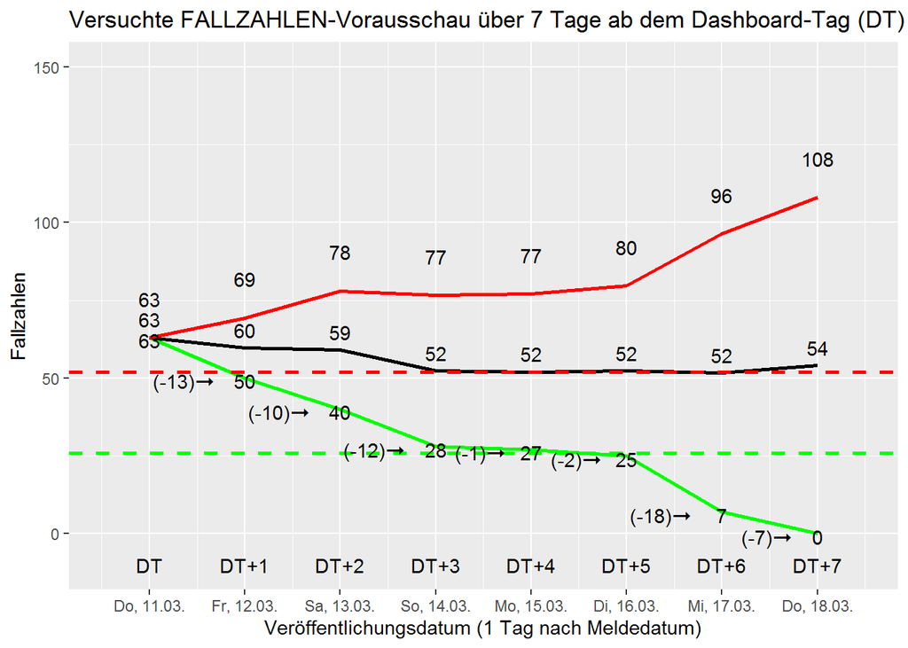